# Homepage: Jia Li

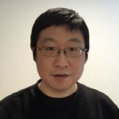

Jia Li[^1], Ph.D.  
Assistant Adjunct Professor  
Department of Civil and Environmental Engineering  
University of California Davis  
email: cejli [at] ucdavis.edu

### Research

My primary research interest is focused on the modeling, control, and behavior design for automated vehicles in complex mixed autonomy environments. I am fascinated by the idea that the non-coordinated interactions of self-interested agents can lead to collective rationality and exploring this idea in my research, leveraging game theory and artificial intelligence tools. A recent work of mine (under review), for example, explicitly derived and analyzed all the equilibria that automated vehicles and human-driven vehicles would reach in general multilane settings. I and my collaborators are also looking at the problem of training automated vehicle behaviors based on massive human-driven trajectory data.

Another line of my research is the data science applications in built environment and safety, where the core problem consists of mining, representation, and interpretation of the hidden relations in the data. Data in built environment often share certain common peculiarities, such as high-dimensionality, latent features, and heterogeneous types and sources, which constitute the major barrier for an in-depth understanding. My current research explores applying machine learning techniques to estimate crash modification factors when direct before-and-after measurements are not available.

### Teaching

I teach the following courses at UC Davis.

- ECI 254: Exploring Data From Built Environment Using R (Winter 2021, Fall 2021).
- ECI 16: Spatial Data Analysis (Winter 2021/2022).
- ECI 161: Transportation System Operations (Spring 2021/2022).

### Grants

My current research receives support from CTech, California Senate Bill-1 (SB-1), and Caltrans.

[^1]: pronounced “jay-ah, lee”